# group_assignment_final

Alan Lee

October 27, 2019

#This R markdown will contain only Q2 and Q3’s solution.

The following cell will define the function used to generate the price randomly for given number of days.

```r
get_price <- function(S0, t){
  # this function will generate the daily price
  # S is the stock price of the previous day,
  K <- 100
  sigma <- 0.5 # realized vol can be 0.3 for [2] or 0.5 for [3]
  drift <- 0 # drift = r - q
  timestep <- 1 / 250
  days <- t / 250
  N <- days / timestep
  p1 <- (drift - 0.5 * sigma * sigma) * timestep
  p2 <- sigma * sqrt(timestep)
  # ss is the simulated price movement for N days
  ss <- rep(S0, N) * c(1, cumprod(rlnorm(N - 1, mean = p1, sd = p2)))
  return(ss)
}
```

Q2P1: This cell will show how accurate the Taylor’s approximation is if applied to actual PnL.

```r
# Question 2 Part 1
taylor_pnl <- function(ss){

  days=length(ss)
  # creating the dataframe
  df <- tibble(S=ss, days=1:days) %>% mutate(days=days-1)
  # calculate delta, gamma, vega and theta.
  opt <- rowwise(df) %>% mutate(
    price = GBSOption("c", S = S, X = 100, Time = (30-days) / 250, r = 0, b = 0, sigma = 0.3)@price,
    delta = GBSGreeks("Delta", "c", S = S, X = 100, Time = (30-days) / 250, r = 0, b = 0, sigma = 0.3),
    gamma = GBSGreeks("Gamma", "c", S = S, X = 100, Time = (30-days) / 250, r = 0, b = 0, sigma = 0.3),
    vega = GBSGreeks("Vega", "c", S = S, X = 100, Time = (30-days) / 250, r = 0, b = 0, sigma = 0.3),
    theta = GBSGreeks("Theta", "c", S = S, X = 100, Time = (30-days) / 250, r = 0, b = 0, sigma = 0.3)
  )
  opt[is.na(opt)] <- 0.0 # fill the last row theta and delta with 0.0
  # Create storage.
  option_pnl_l = list(1:nrow(opt)-1)
  approx_pnl_l = list(1:nrow(opt)-1)
  for (pos in 2:nrow(opt)){
    prev_opt_price <- opt$price[[pos-1]]
    # using in-built from R GBSoptions
    option_pnl <- GBSOption("c", S = opt$S[pos], X = 100,
                            Time = (30-opt$days[pos]) / 250, r = 0, b = 0, sigma = 0.3)@price - prev_opt_price

    option_pnl_l[[pos-1]] = option_pnl
    # print(option_pnl)
    approxi_pnl <- (opt$delta[[pos-1]] * (opt$S[[pos]] - opt$S[[pos-1]])) +
      (0.5 * opt$gamma[[pos-1]] * (opt$S[[pos]] - opt$S[[pos-1]]) ** 2) +
      (opt$vega[[pos-1]] * 0) + (opt$theta[[pos-1]] * 1/250)
    # print(approxi_pnl)
    approx_pnl_l[[pos-1]]<-approxi_pnl
  }

  option_pnl_l<-as.numeric(unlist(option_pnl_l))
  approx_pnl_l<-as.numeric(unlist(approx_pnl_l))

  df_results <- tibble(R_pnl=option_pnl_l, approxi_pnl=approx_pnl_l, days=1:(length(ss)-1))

  df_results<- df_results %>% mutate(`absolute error`=(abs(R_pnl-approxi_pnl)))

  return(df_results)
}
# creating the price, and running part 1 code
stock_prices = get_price(100,31)
Q1_results =  taylor_pnl(stock_prices)
Q1_results
```

```
## # A tibble: 30 x 4
##       R_pnl approxi_pnl  days `absolute error`
##       <dbl>       <dbl> <int>            <dbl>
##  1 -1.57       -1.58        1         0.00579
##  2  0.318       0.320       2         0.00258
##  3 -1.69       -1.69        3         0.000686
##  4 -1.11       -0.755       4         0.353
##  5 -0.0608     -0.0612      5         0.000330
##  6  0.00472     0.00563     6         0.000911
##  7  0.00919     0.0106      7         0.00139
##  8 -0.0348     -0.0328      8         0.00201
##  9  0.00121     0.00166     9         0.000447
## 10 -0.0107     -0.00140    10         0.00933
## # ... with 20 more rows
```

Q2P2: If the realised volatility and implied volatility is the same, `sum(0.5*Gamma*deltaS^2+dt_Theta*dt)` approximates to 0.

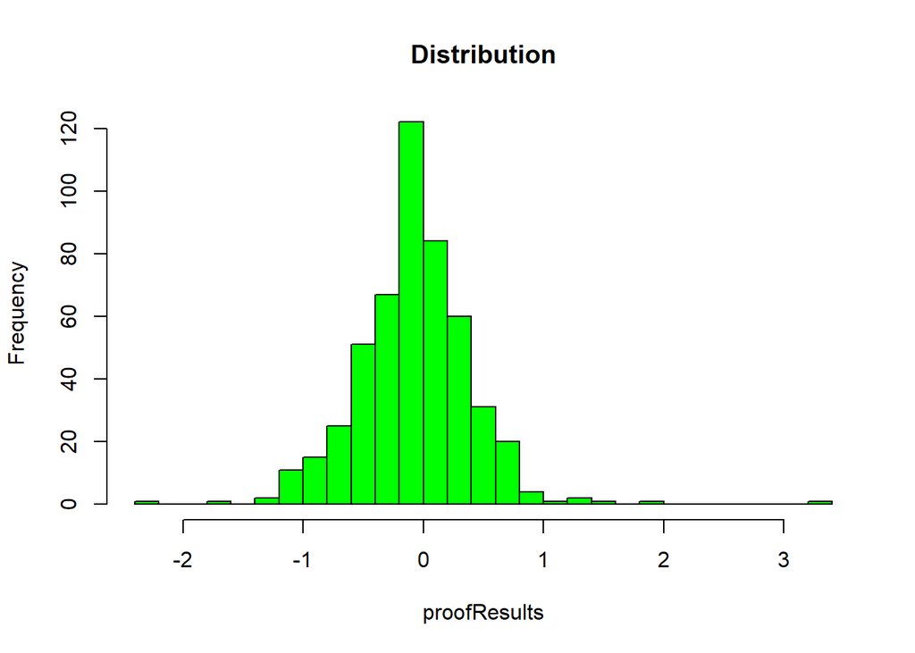

```r
# Question 1 part 2
# 1) calculate the implied volatility given X is known. r and b known.
# we need to make realised volatility same as implied volatility,
# price = price of options
Gamma_theta_neutralise<- function(ss){
  realised_var = 0.0
  for (pos in 2:length(ss)){
    rt = log(ss[pos]) - log(ss[pos-1])
    realised_var <- realised_var+rt**2
  }
  realised_vol = ((250/30)*realised_var)**0.5

  # now volatility is realised_vol calculated, create the df as above
  days <- length(ss)
  df <- tibble(S=ss, days=1:days) %>% mutate(days=days-1)
  # calculate delta, gamma, vega and theta.
  opt <- rowwise(df) %>% mutate(
    price = GBSOption("c", S = S, X = 100, Time = (30-days) / 250, r = 0, b = 0, sigma = realised_vol)@price,
    delta = GBSGreeks("Delta", "c", S = S, X = 100, Time = (30-days) / 250, r = 0, b = 0, sigma = realised_vol),
    gamma = GBSGreeks("Gamma", "c", S = S, X = 100, Time = (30-days) / 250, r = 0, b = 0, sigma = realised_vol),
    vega = GBSGreeks("Vega", "c", S = S, X = 100, Time = (30-days) / 250, r = 0, b = 0, sigma = realised_vol),
    theta = GBSGreeks("Theta", "c", S = S, X = 100, Time = (30-days) / 250, r = 0, b = 0, sigma = realised_vol)
  )

  # now prove that the equation given in the formula is correct
  opt[is.na(opt)] <- 0.0

  # do it another way, and define dt.
  opt$lag_S=dplyr::lag(opt$S, 1)
  dt = 1/250
  result_opt <- opt%>%mutate(delta_S=S-lag_S) %>% .[-1,] %>% mutate(individual_term=(0.5*gamma*(delta_S^2)+theta*dt))

  results = sum(result_opt$individual_term)
  return(results)
}

# Question 2 part 2 driver code.
proofResults = c(1:500)
for (i in 1:500){
  stock_prices = get_price(100,31)
  proofResults[i] <- Gamma_theta_neutralise(stock_prices)
}
# plotting the histogram to see if distribution centre around 0.
hist(proofResults, main="Distribution", breaks=40, col=c("green"))
```